```python
import numpy as np
import matplotlib.pyplot as plt
```

# A

$y'' = a^2 y$

$y(0)=1, y'(0)=-a$

$y(x) = e^{-ax}$

$u(x) := y'(x)$

$(y', u') = (u, a^2y)$

$(y(0), u(0)) = (1, -a)$

# B

```python
def analytic(x, a):
    return np.exp(-a * x)
```

```python
def F(yu, a):
    return np.array(yu[::-1]) * np.array([1, a**2])
```

```python
def euler(f, f0, N, interval=(0, 10)):
    a, b = interval
    h = (b - a) / N
    xs = np.arange(a, b + h / 2, h)
    ys = [f0]
    for x in xs[:-1]:
        y_next = ys[-1] + f(x, ys[-1]) * h
        ys.append(y_next)
    return xs, ys
```

```python
As = [1, 2, 3, np.sqrt(20)]
```

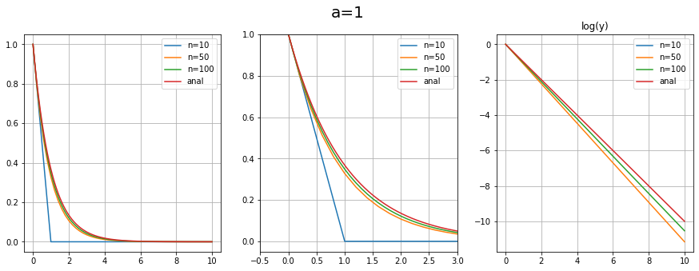

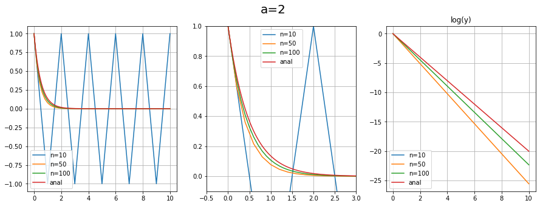

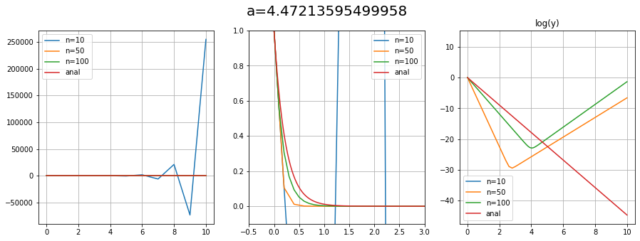

```python
plt.rcParams['figure.figsize'] = 15, 5
for a in As:
    def plot(xs, ys, axs, label):
        axs[0].plot(xs, ys, label=label)
        axs[1].plot(xs, ys, label=label)
        axs[2].plot(xs, [np.log(y) for y in ys], label=label)
        axs[1].set_ybound(lower=max(-0.1, axs[1].get_ybound()[0]),upper=min(1, axs[1].get_ybound()[1]))
        axs[1].set_xbound(upper=3)
    fig, axs = plt.subplots(1, 3)
    f = lambda x, y : F(y, a)
    f0 = np.array([1, -a])
    for n in [10, 50, 100]:
        xs, ys = euler(f, f0, n)
        ys = [y[0] for y in ys]
        ys_log = [np.log(y) for y in ys]
        plot(xs, ys, axs, "n={}".format(n))
    xs = np.arange(0, 10.001, 0.01)
    ys = [analytic(x, a) for x in xs]
    plot(xs, ys, axs, "anal")
    for ax in axs:
        ax.grid()
        ax.legend()
    axs[2].set_title("log(y)")
    fig.suptitle("a={}".format(a), fontsize=20)
    fig.show()
```

[output not shown]

# C + D

```python
def runge_kutta(f, f0, N, interval=(0, 10), beta=1 / 2):
    a, b = interval
    h = (b - a) / N
    xs = np.arange(a, b + h / 2, h)
    ys = [f0]
    for x in xs[:-1]:
        y = ys[-1]
        fxy = f(x, y)
        y_next = y + h * ((1 - beta) * fxy + beta * f(x + h /
                                                      (2 * beta), y + h /
                                                      (2 * beta) * fxy))
        ys.append(y_next)
    return xs, ys
```

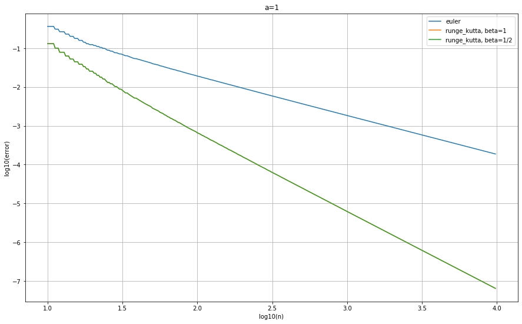

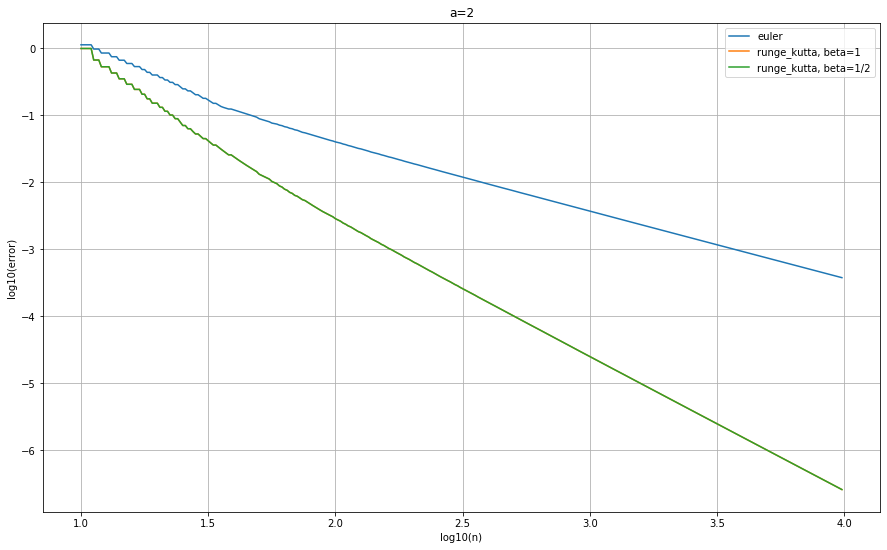

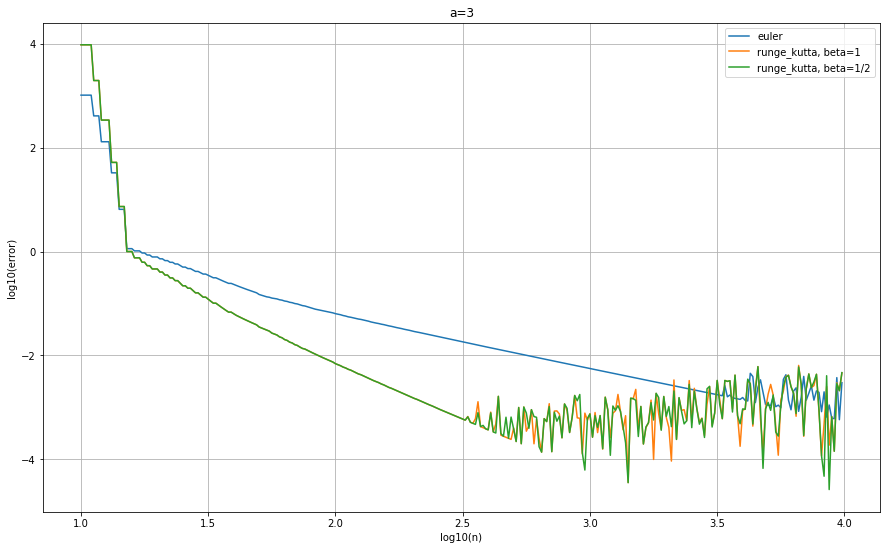

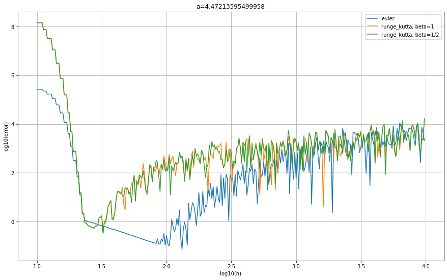

```python
plt.rcParams['figure.figsize'] = 15, 9
for a in As:
    f = lambda x, y : F(y, a)
    f0 = np.array([1, -a])
    errors_e, errors1, errors2 = [], [], []
    ns_logs = np.arange(1, 4, 0.01)
    ns = [int(np.power(10, nlog)) for nlog in ns_logs]
    for n in ns:
        xs, ys = euler(f, f0, n)
        ys = [y[0] for y in ys]
        errors_e.append(np.max([np.abs(y - analytic(x, a)) for y, x in zip(ys, xs)]))

        xs, ys = runge_kutta(f, f0, n, beta=1/2)
        ys = [y[0] for y in ys]
        errors1.append(np.max([np.abs(y - analytic(x, a)) for y, x in zip(ys, xs)]))

        xs, ys = runge_kutta(f, f0, n, beta=1)
        ys = [y[0] for y in ys]
        errors2.append(np.max([np.abs(y - analytic(x, a)) for y, x in zip(ys, xs)]))

    plt.plot(ns_logs, np.log10(np.array(errors_e)), label="euler")
    plt.plot(ns_logs, np.log10(np.array(errors2)), label="runge_kutta, beta=1")
    plt.plot(ns_logs, np.log10(np.array(errors1)), label="runge_kutta, beta=1/2")
    plt.grid()
    plt.xlabel("log10(n)")
    plt.ylabel("log10(error)")
    plt.title("a={}".format(a))
    plt.legend()
    plt.show()
```

Для метода Эйлера видна зависимость первого порядка, поэтому точность $10^{-3}$ достигается на $n$ порядка 2000-3000. Для метода Рунге-Кутты второго порядка, зависимость погрешности согласуется с теорией (второй порядок), так что для точности $10^{-3}$ требуется около 100-200 интервалов.

При большом параметре $a$ происходит интересное явление, когда ошибка начинает расти при больших $n$. Это связано это с тем, что в какой-то момент обе переменные $y, u$ становятся одного знака, и метод начинает решать задачу Коши с такими начальными данными ($y(x_0) \cdot y'(x_0) >0$). Поскольку общее решение системы это $\alpha e^{ax}+\beta e^{-ax}$, то результат стремится к решению где $\alpha!=0$.

Для метода эйлера можно строго расписать:

$(y, u)_{n+1} = (E+hA)(y,u)_n$

$A = \begin{pmatrix} 0& 1\\ a^2& 0 \end{pmatrix}$

$A^2 = a^2 E$

$(E+hA)^n = \sum\limits_0^n C_n^k h^k a^k \cdot (\frac{1}{a}A)^{k\,mod\,2}= \frac{(1+ha)^n+(1-ha)^n}{2}E + \frac{(1+ha)^n-(1-ha)^n}{2} \frac{1}{a}A$

Из-за погрешности $(y_k+\frac{1}{a}u_k) \neq 0$ в какой-то момент, поэтому решение расходится

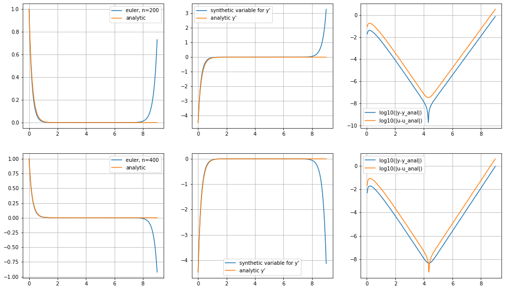

```python
plt.rcParams['figure.figsize'] = 17, 10
a = np.sqrt(20)
f = lambda x, y: F(y, a)
f0 = np.array([1, -a])
ns = [200, 400]
fig, axs = plt.subplots(2, 3)
for i, n in enumerate(ns):
    xs, ys_ = euler(f, f0, n, interval=(0, 9))
    ys = [y[0] for y in ys_]
    us = [y[1] for y in ys_]
    ys_anal = np.array([analytic(x, a) for x in xs])
    us_anal = -a * ys_anal

    axs[i][0].plot(xs, ys, label="euler, n={}".format(n))
    axs[i][0].plot(xs, ys_anal, label="analytic")
    axs[i][0].grid()
    axs[i][0].legend()

    axs[i][1].plot(xs, us, label="synthetic variable for y'")
    axs[i][1].plot(xs, us_anal, label="analytic y'")
    axs[i][1].grid()
    axs[i][1].legend()

    axs[i][2].plot(xs, np.log10(np.abs(ys-ys_anal)), label="log10(|y-y_anal|)")
    axs[i][2].plot(xs, np.log10(np.abs(us-us_anal)), label="log10(|u-u_anal|)")
    axs[i][2].grid()
    axs[i][2].legend()

fig.show()
```